# Reno Production Trees

2024-08-22

The following analysis shows the affects of estimated decision trees on different segments of the population. In general, pre-segmentation of the population improves model fit when comparing back to the survey by market segment.

# W_HBW by Vehicle Sufficiency

## v0

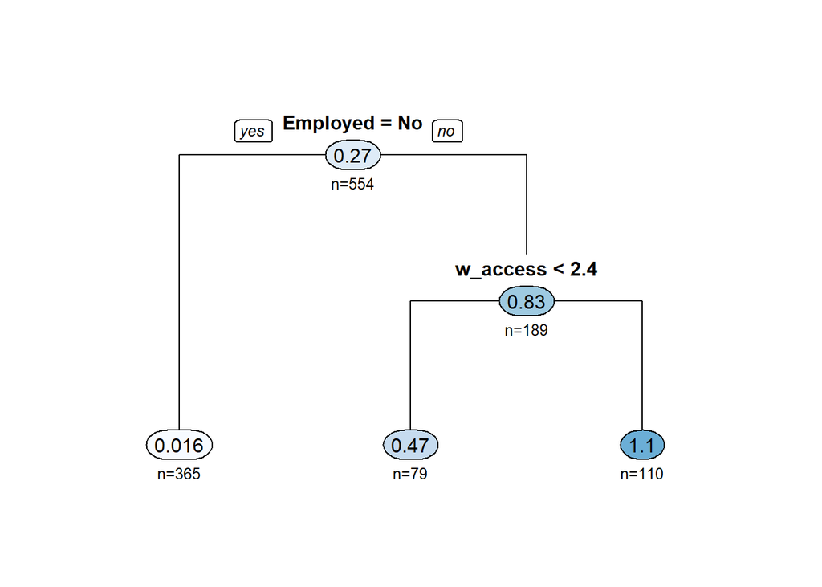

## vi

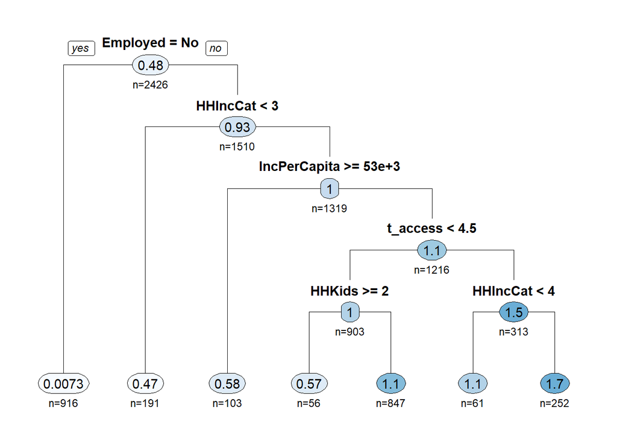

## vs

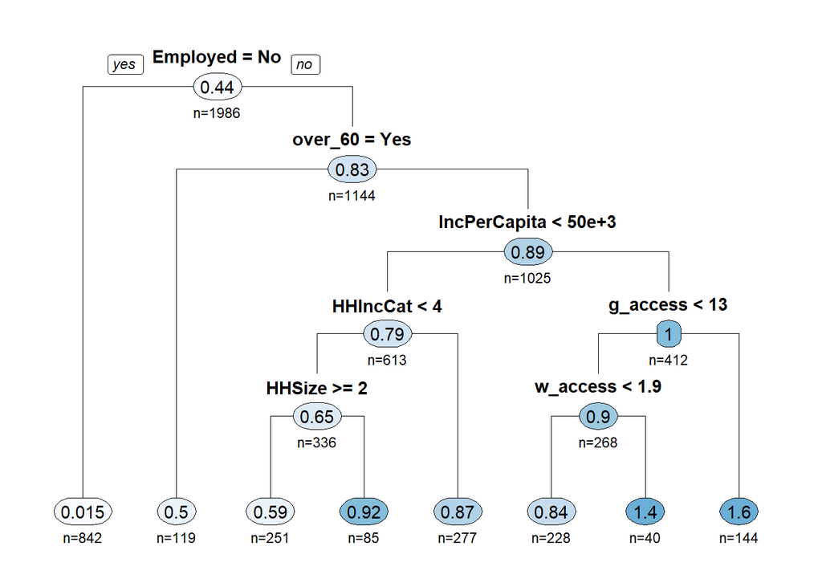

# W_HBO by Vehicle Sufficiency

## v0

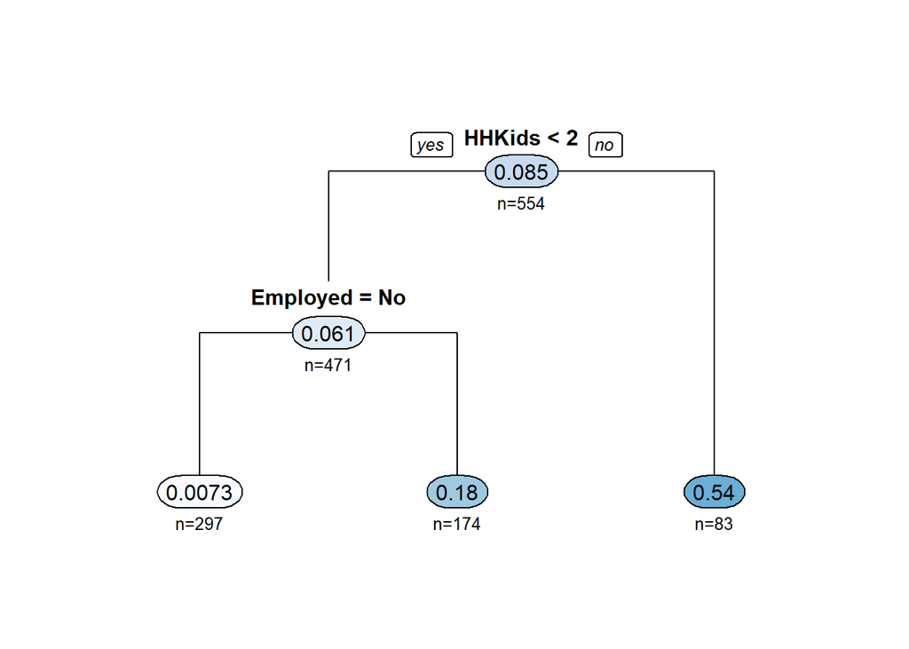

## vi

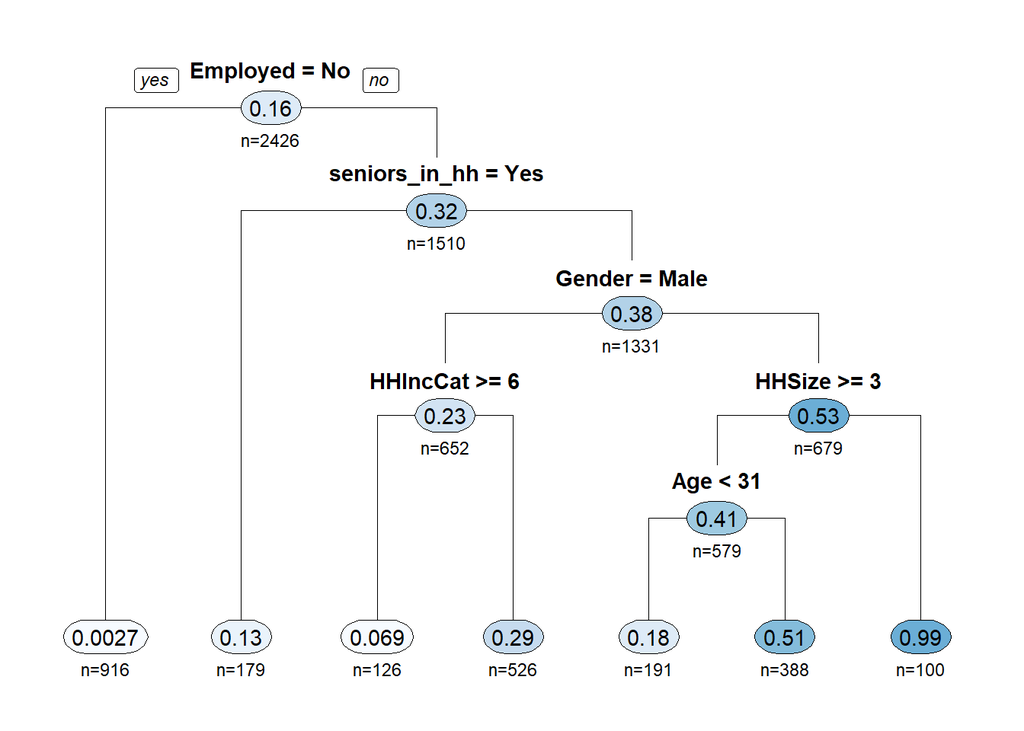

## vs

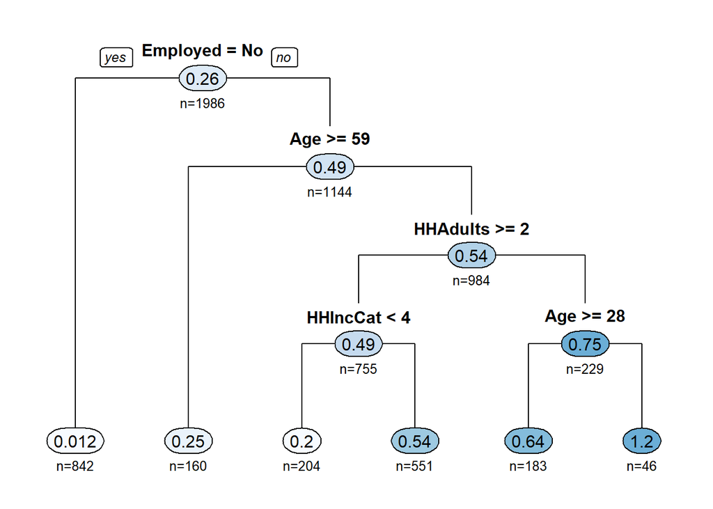

# N_HBSR by Vehicle Sufficiency

## v0

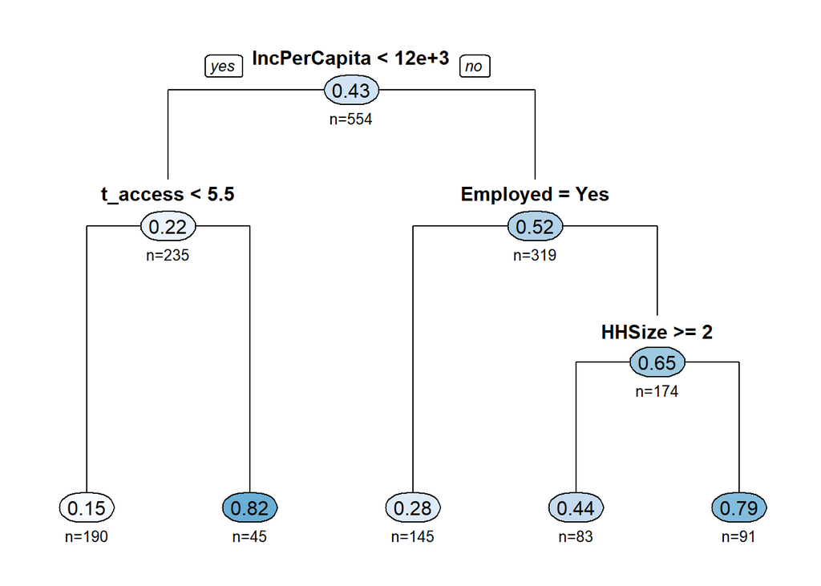

## vi

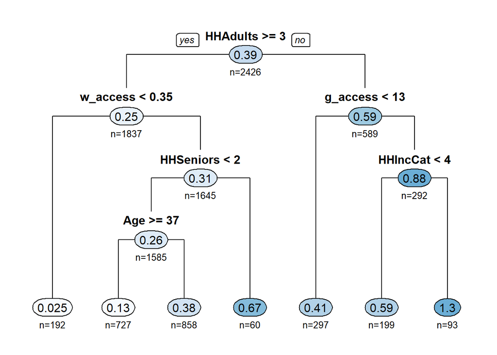

## vs

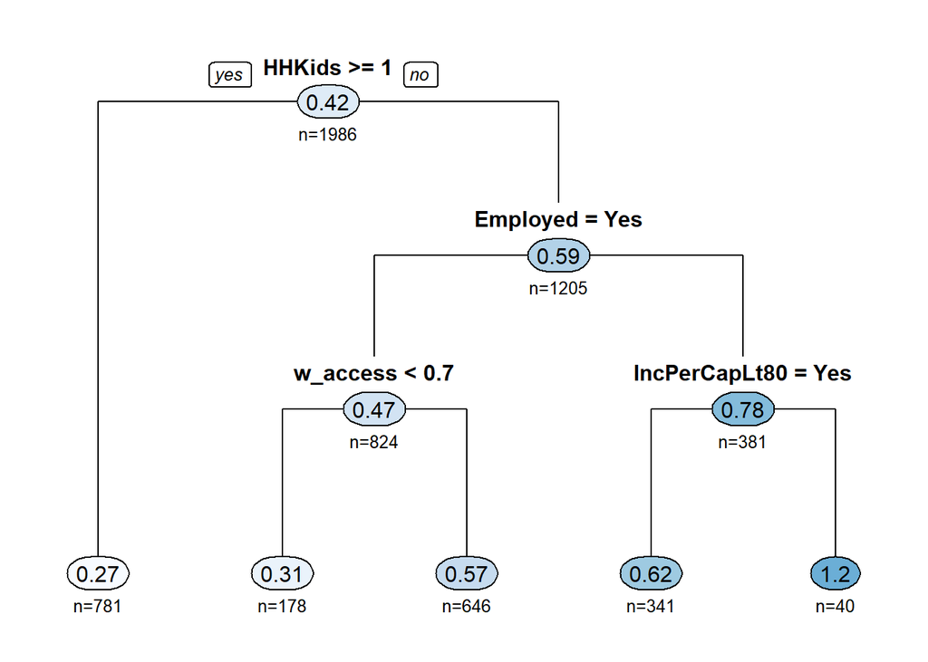

# N_HBO by Vehicle Sufficiency

## v0

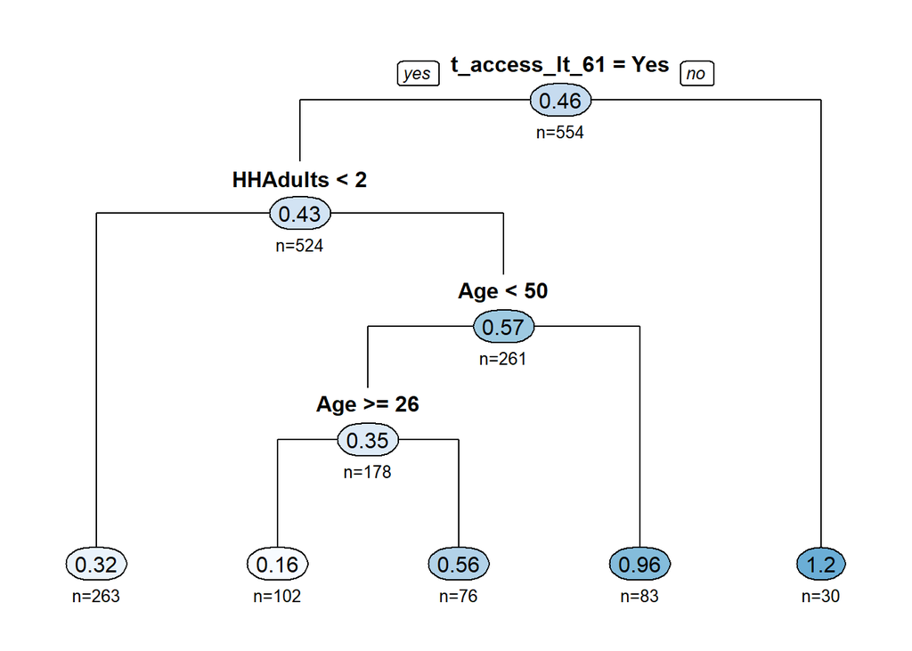

## vi

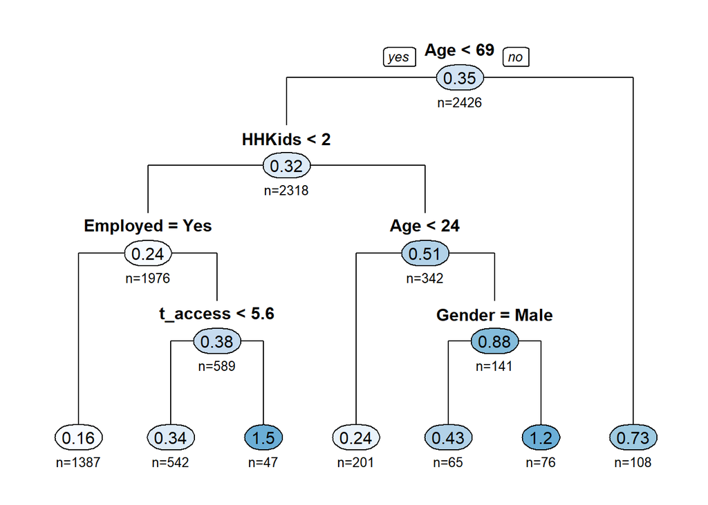

## vs

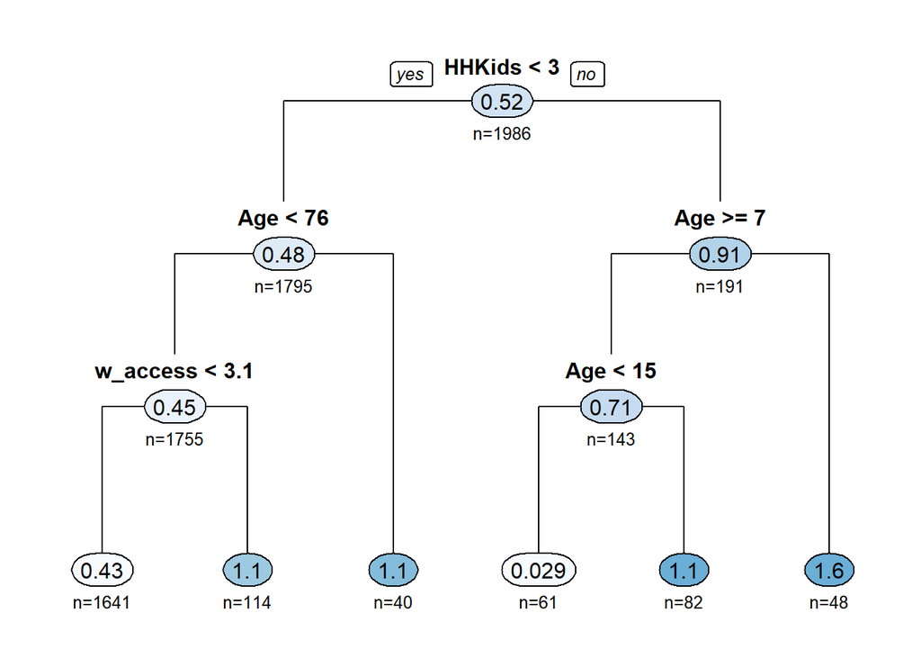

# N_HBSCH

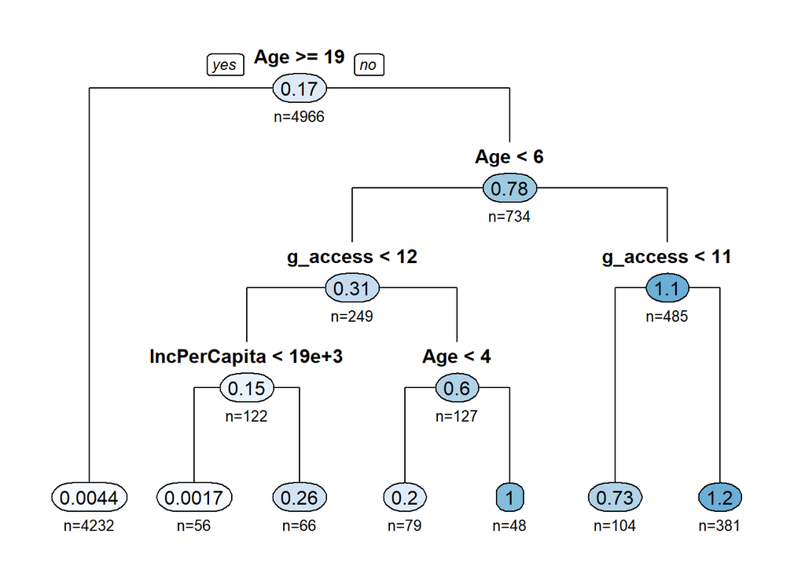

# N_HBSHP by Vehicle Sufficiency

## v0

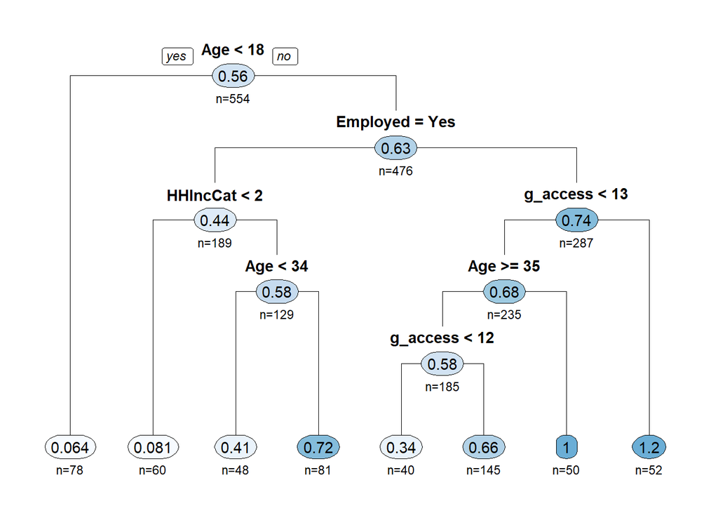

## vi

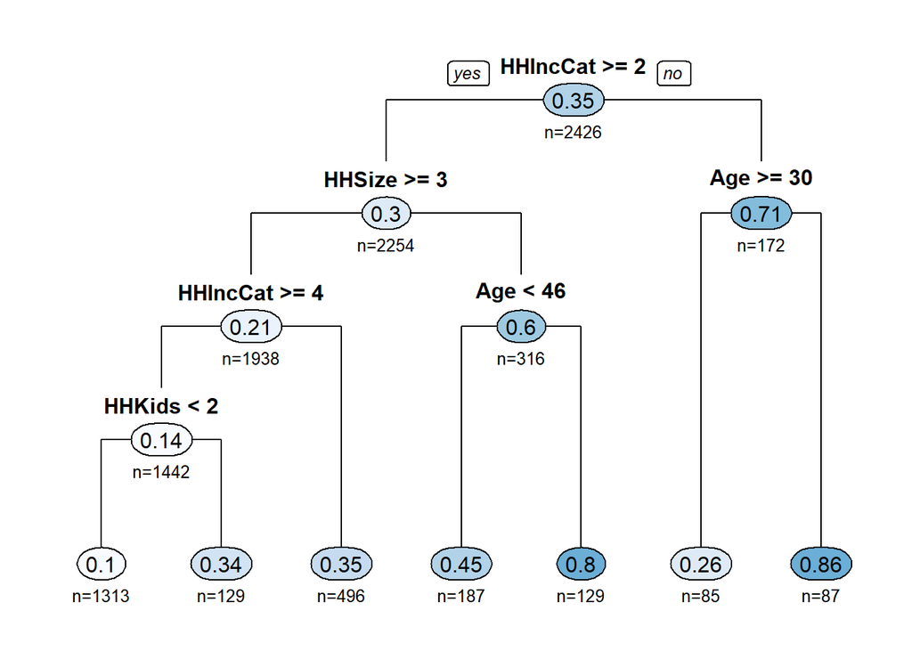

## vs

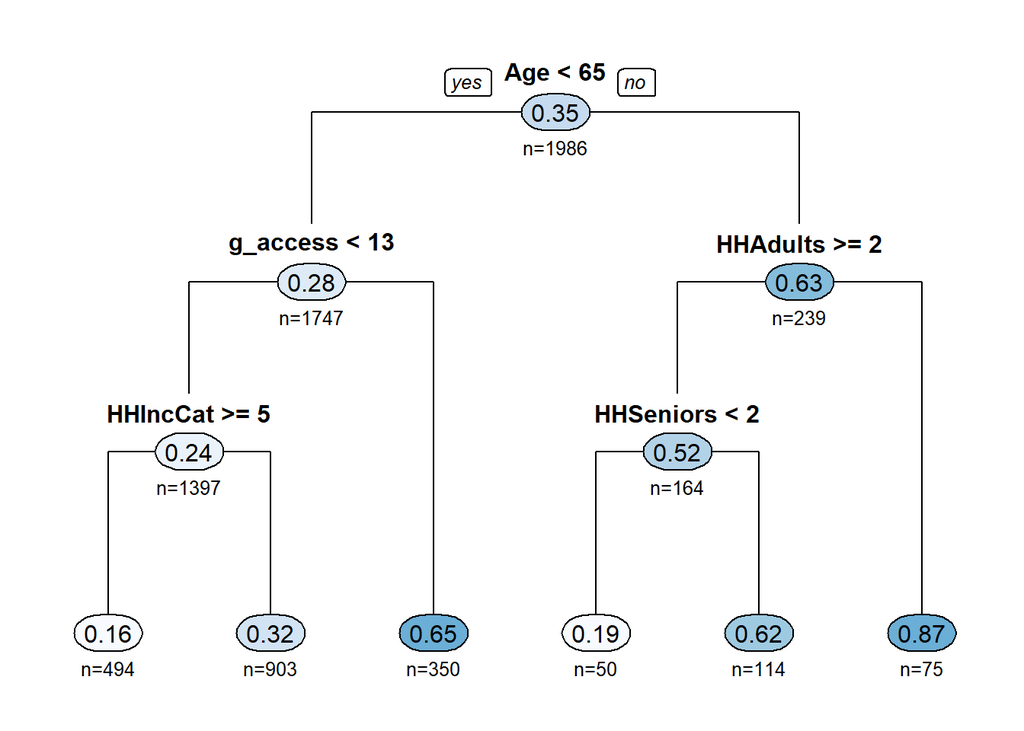

# Calibration

Calibrating the production rates is done to ensure that the final model is producing the same number of trips per person on average as the survey. One complicating factor in this comparison is that the survey and model socio-economic data have different total populations.

- Survey: 476,187
- Model: 523,542

As a consequence, the survey trip totals are increased by 1.1 and then compared to model results. The table below shows the production model results compared back to the total trips in the survey (factored up). While some purposes are higher or lower than the survey, the model does a good job of predicing total trips even before calibration.

| Trip Type | Observed | Modelled | Difference | %Difference |
| --- | --- | --- | --- | --- |
| N_HBO | 237,004 | 271,029 | 34,026 | 14 |
| N_HBSCH | 91,037 | 105,942 | 14,905 | 16 |
| N_HBSHP | 190,471 | 182,342 | -8,130 | -4 |
| N_HBSR | 215,651 | 204,147 | -11,504 | -5 |
| W_HBO | 111,315 | 118,982 | 7,668 | 7 |
| W_HBW | 232,059 | 240,432 | 8,374 | 4 |
| All | 1,077,536 | 1,122,874 | 45,338 | 4 |

The calibration factors below are the ratio of the observed to modeled trips. These are applied by trip type and auto sufficiency segment to ensure total trip making matches the survey (based on trip weight).

| Trip Type | segment | Factor |
| --- | --- | --- |
| N_HBO | v0 | 0.78 |
| N_HBO | vi | 1.35 |
| N_HBO | vs | 0.76 |
| N_HBSCH |  | 0.86 |
| N_HBSHP | v0 | 2.10 |
| N_HBSHP | vi | 1.50 |
| N_HBSHP | vs | 0.80 |
| N_HBSR | v0 | 1.86 |
| N_HBSR | vi | 1.56 |
| N_HBSR | vs | 0.85 |
| W_HBO | v0 | 0.87 |
| W_HBO | vi | 1.33 |
| W_HBO | vs | 0.84 |
| W_HBW | v0 | 1.27 |
| W_HBW | vi | 1.38 |
| W_HBW | vs | 0.79 |